# WebアプリでABテストを実践する

UPDATE: 2024-01-30 14:17:49.392032

# はじめに

このノートは、Udemyで提供されている[A/B Testing in Python](https://www.udemy.com/course/ab-testing-in-python/)コースのPythonスクリプトをRスクリプトに変換したものをまとめているノート。

## メトリクスの計算

2種類のユーザーアクティビティデータセットを使用する。

- `userid`: ユーザーID
- `dt`: アプリの起動日
- `activity_level`: 1日にアプリを起動した回数
- `ctr`: ユーザーがクリックした広告数 / そのユーザーが1日に接触した広告総数

`activity_level`は、ユーザーがアプリ内でアクティブになった回数を意味する。つまり、アプリを開いた回数を指す。

```r
library(tidyverse)
library(scales)
activity_pretest <- read_csv('~/Desktop/activity_pretest.csv')
head(activity_pretest, 10)
```

```
## # A tibble: 10 × 3
##    userid                               dt         activity_level
##    <chr>                                <date>              <dbl>
##  1 a5b70ae7-f07c-4773-9df4-ce112bc9dc48 2021-10-01              0
##  2 d2646662-269f-49de-aab1-8776afced9a3 2021-10-01              0
##  3 c4d1cfa8-283d-49ad-a894-90aedc39c798 2021-10-01              0
##  4 6889f87f-5356-4904-a35a-6ea5020011db 2021-10-01              0
##  5 dbee604c-474a-4c9d-b013-508e5a0e3059 2021-10-01              0
##  6 9b2f41cf-350d-4073-b9d4-3848d0c0b1b5 2021-10-01              0
##  7 82b1f3a8-57cc-4d2e-96c4-3664150f53e5 2021-10-01              0
##  8 9dcc4eed-c222-4323-b2f6-d91edaba5d0e 2021-10-01              0
##  9 c55c0d67-6b95-4d19-bf7d-4c33911da83f 2021-10-01              0
## 10 40992374-c58b-4004-a7b4-1aa737a4b636 2021-10-01              0
```

それぞれの`activity_level`ごとに何件のレコードがあるかを調べる。`activity_level`は0から20までのレベルがあることがわかる。

```r
activity_pretest %>%
  group_by(activity_level) %>%
  count() %>%
  arrange(n)
```

```
## # A tibble: 21 × 2
## # Groups:   activity_level [21]
##    activity_level     n
##             <dbl> <int>
##  1             20 24520
##  2              7 48339
##  3             17 48395
##  4              8 48396
##  5             13 48534
##  6              4 48556
##  7             15 48599
##  8             14 48620
##  9              3 48659
## 10              1 48732
## # ℹ 11 more rows
```

`dt, activity_level`ごとに、`activity_level`が0より大きいレコードを対象に、レコード数をカウントする。 `activity_level`が1から19はほぼ均等に分布しており、ユーザーがおおよそ1600人いることがわかる。一方で、`activity_level`が20の場合、1日におおよそ800人のユーザーがいる。このようになっている背景はわからないが、このデータは19より大きいものは全て20として扱っているのかもしれないし、ボットなどの可能性もある。

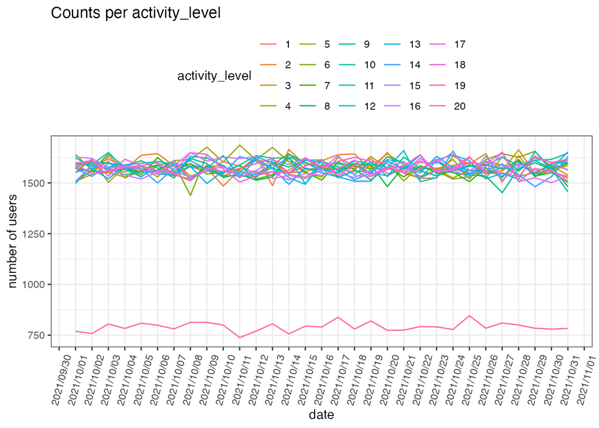

```r
# activity_pretest %>%
#   group_by(activity_level) %>%
#   summarise(
#     count = n(),
#     unique = n_distinct(userid)
#   )

activity_pretest %>%
  filter(activity_level > 0) %>%
  group_by(dt, activity_level) %>%
  count() %>%
  ggplot(., aes(dt, n, col = as.factor(activity_level))) +
  geom_line() +
  scale_x_date(
    labels = date_format("%Y/%m/%d"),
    breaks = "1 day",
    minor_breaks = "1 day"
  )  + labs(
    title = "Counts per activity_level",
    x = "date",
    y = "number of users",
    col = "activity_level"
  ) +
  theme_bw() +
  theme(
    axis.text.x = element_text(
      angle = 75,
      vjust = 0.2,
      hjust = 0.2
    ),
    legend.position = 'top',
  )
```

メトリクスを計算する段階に移る。日次アクティブユーザーを計算する。`userid`が1日の`activity_level`が0でない場合に、日次アクティブユーザーとしてカウントされるとする。

```r
activity <- activity_pretest %>%
  filter(activity_level > 0) %>%
  group_by(dt) %>%
  count() %>%
  ungroup()
activity
```

```
## # A tibble: 31 × 2
##    dt             n
##    <date>     <int>
##  1 2021-10-01 30634
##  2 2021-10-02 30775
##  3 2021-10-03 30785
##  4 2021-10-04 30599
##  5 2021-10-05 30588
##  6 2021-10-06 30639
##  7 2021-10-07 30637
##  8 2021-10-08 30600
##  9 2021-10-09 30902
## 10 2021-10-10 30581
## # ℹ 21 more rows
```

1か月分のデータがあり、日次アクティブユーザーの平均が約30673人。標準偏差は約90で、最小値は約30490人、最大値は約30900人。

```r
activity %>%
  summarise(
    count = n(),
    mean = mean(n),
    std = sd(n),
    min = min(n),
    `q25%` = quantile(n, 0.25),
    `q50%` = quantile(n, 0.50),
    `q75%` = quantile(n, 0.75),
    max = max(n)
  )
```

```
## # A tibble: 1 × 8
##   count   mean   std   min `q25%` `q50%` `q75%`   max
##   <int>  <dbl> <dbl> <int>  <dbl>  <dbl>  <dbl> <int>
## 1    31 30673.  91.0 30489  30608  30661 30728. 30902
```

可視化すると、10月の初めから終わりまで、安定して日次アクティブユーザーが存在していることがわかる。

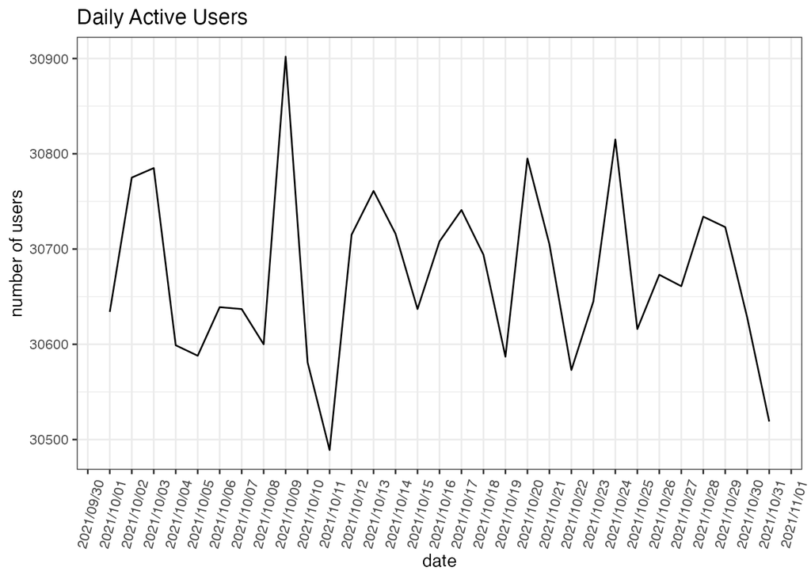

```r
activity %>%
  ggplot(., aes(dt, n)) +
  geom_line() +
  scale_x_date(
    labels = date_format("%Y/%m/%d"),
    breaks = "1 day",
    minor_breaks = "1 day"
  )  + labs(
    title = "Daily Active Users",
    x = "date",
    y = "number of users"
    ) +
  theme_bw() +
  theme(axis.text.x = element_text(
    angle = 75,
    vjust = 0.2,
    hjust = 0.2
  ))
```

次に、クリックスルーレートを計算する。

```r
ctr_pretest <- read_csv('~/Desktop/ctr_pretest.csv')
head(ctr_pretest, 10)
```

```
## # A tibble: 10 × 3
##    userid                               dt           ctr
##    <chr>                                <date>     <dbl>
##  1 4b328144-df4b-47b1-a804-09834942dce0 2021-10-01  34.3
##  2 34ace777-5e9d-40b3-a859-4145d0c35c8d 2021-10-01  34.7
##  3 8028cccf-19c3-4c0e-b5b2-e707e15d2d83 2021-10-01  34.8
##  4 652b3c9c-5e29-4bf0-9373-924687b1567e 2021-10-01  35.4
##  5 45b57434-4666-4b57-9798-35489dc1092a 2021-10-01  35.0
##  6 83d875d5-bb3e-433c-ae0e-a851dca902b3 2021-10-01  34.5
##  7 33f95ebe-71ec-4a1a-8670-5db74ba32779 2021-10-01  35.6
##  8 79e7125f-fcc7-440d-8621-e090c78015b6 2021-10-01  34.9
##  9 9151badd-368c-46cc-a86c-d2d25034ce25 2021-10-01  33.2
## 10 b1917103-6199-42bd-bf72-c97ec31937a8 2021-10-01  33.1
```

ここでのクリックスルーレートは、ユーザーが1日に特定の数の広告を見て、そのうち33%をクリックしたことを意味する。標準偏差も非常に小さいため、クリックスルーレートデータは非常に安定している。最小値は30%で、最大値は36%。

```r
ctr_pretest %>%
  summarise(
    count = n(),
    mean = mean(ctr),
    std = sd(ctr),
    min = min(ctr),
    `q25%` = quantile(ctr, 0.25),
    `q50%` = quantile(ctr, 0.50),
    `q75%` = quantile(ctr, 0.75),
    max = max(ctr)
  )
```

```
## # A tibble: 1 × 8
##    count  mean   std   min `q25%` `q50%` `q75%`   max
##    <int> <dbl> <dbl> <dbl>  <dbl>  <dbl>  <dbl> <dbl>
## 1 950875  33.0  1.73    30   31.5     33   34.5    36
```

同じデータセットを使用して、クリックスルーレートの日次平均を計算して可視化する。

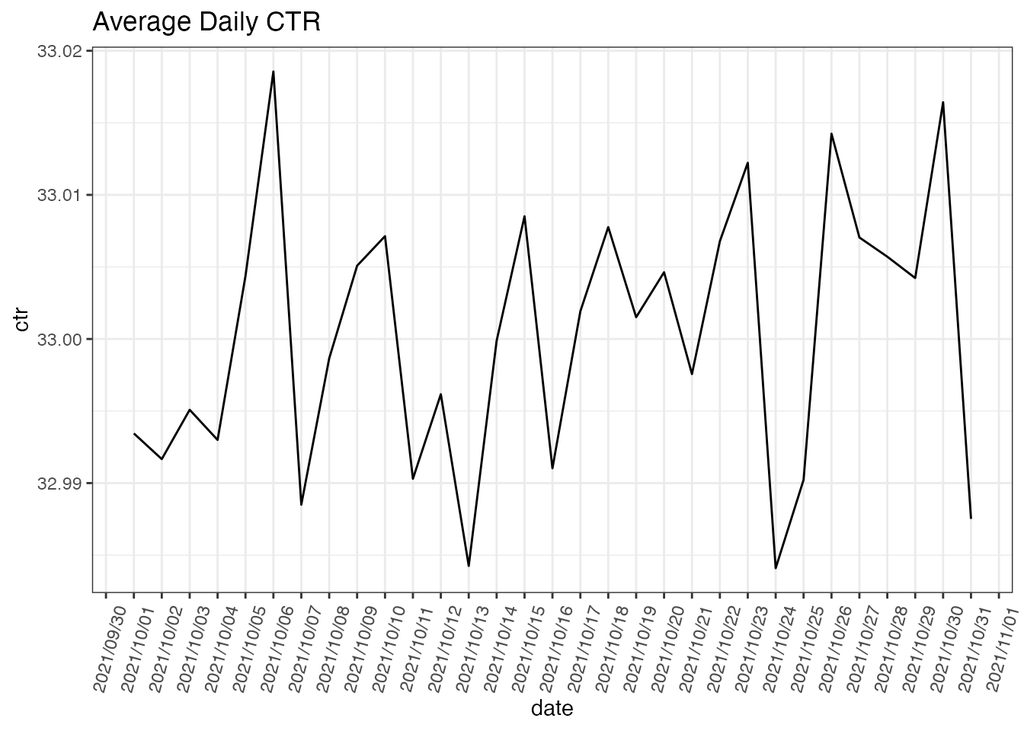

```r
ctr <- ctr_pretest %>%
  group_by(dt) %>%
  summarise(ctr = mean(ctr)) %>%
  ungroup()

ctr %>%
  ggplot(., aes(dt, ctr)) +
  geom_line() +
  scale_x_date(
    labels = date_format("%Y/%m/%d"),
    breaks = "1 day",
    minor_breaks = "1 day"
  )  + labs(
    title = "Average Daily CTR",
    x = "date",
    y = "ctr"
    ) +
  theme_bw() +
  theme(axis.text.x = element_text(
    angle = 75,
    vjust = 0.2,
    hjust = 0.2
  ))
```

## 実験の計画

正しいテスト対象のアイデアを見つける方法は何か？これは定量的および定性的分析を行い、共通感覚とビジネス領域を知ることを通じて行われます。

まず第一に、テストが影響する規模を確認することが非常に重要。導入しようとしている機能または製品の領域の変更についてｍ既に持っているデータを分析し、テストの影響を推定する。たとえば、製品のメインページに変更を加えたい場合、ほとんどのユーザーがメインページに移動するため、変更は非常に大きな影響を与える。一方で、小さなエリアに変更を加えたい場合、一部のユーザーがアクセスできず、ユーザーにはあまり使用されないかもしれない。そのため、テストの影響は低く、その種の機能をテストする意欲が低い。

次に、変更したい振る舞いの要因を調査することが重要。基本的には、ユーザーが特定のページを離れる理由を理解できるようにする。ユーザーリサーチ、つまり質的分析、アンケート、ユーザーインタビュー、またはアプリと対話するユーザーを観察する方法を通じて行われる。また、どのようなアクションをユーザーがページを離れる前に実際に行うかを示すことができる定量的分析を通じても行われる。

また、適切な仮説を定義することも重要。基本的に、仮説は、新しい機能または製品への変更を導入した場合に何が起こるかを予想する。「変更した場合、テストで何が起こると予想しますか？」という形で表現される。これは具体的かつ測定可能であるべきで、テストのために変更および制御する独立変数を識別し、テストの影響を示す従属変数を示す必要がある。

つまり、仮説テストのために何かを導入したことによって、メトリクスの変更を見ることができるはず。私たちの仮説は、ユーザーがカスタマイズされた広告を持つと、広告がより関連性があがるため、広告をクリックする可能性が高まり、製品を購入する可能性が高まり、これによりユーザー満足度が向上し、会社のアフィリエイト収益が向上するはず。

したがって、この場合、基本仮説、すなわち仮説の1つは、カスタマイズされた広告を導入することで、広告がより関連性があがるため、ユーザーが広告をクリックしやすくなり、したがってクリック率がユーザーあたりに増加する。

1つの興味のあるメトリクスのほかに、いわゆるガードレールメトリクスを定義することも一般的。ポジティブな方法でいくつかのメトリクスを変更するだけでなく、ビジネスにとって重要ないくつかのクリティカルなビジネスメトリクスが負の影響を受けないようにすることを確認する。これらの重要なメトリクスについて、どのくらい影響を与えた場合に、テストを成功とみなすことができるかを定義する必要がある。通常、リテンションやエンゲージメントメトリクス、エラー数やクラッシュ数などのより技術的なメトリクスがガードレールメトリクスとして使用されることが一般的で、ユーザーアクティビティに関しては、リテンション、週間アクティブユーザー、月間アクティブユーザー、エラーレート、クラッシュレートなどがガードレールメトリクスとして考えられる。

## ABテストの設定

テストをいつ開始し、どれくらい実行するか、そしてテストの各ポイントでどれくらいのユーザーが露出するかを決定する必要がある。これらに影響を与える多くの要因があり、非常に頻繁に、100％原則どおりに実行できないことがある。

たとえば、特定の日付で実行中または開始されるマーケティングキャンペーンがあるかもしれない。そのため、新機能を持たないコントロールグループが非常に少ない場合がある。また、同時に実行されているABテストがあるかもしれないため、いくつかが終了するのを待たなければならないかもしれない。

テストの期間、コントロールグループのサイズ、新機能を持つテストグループまたは異なるバリエーションを持つ複数のテストグループのサイズを決定するために、最小検出可能効果(MDE: Minimum Detectable Effect)を知る必要がある。一定の確実性をもって検出したいリフトの最小値を見積もることで、テストにどれだけのトラフィックや時間を投資するかをシミュレーションする。

利用可能なデータに基づいて、最小検出可能効果(MDE)を定義できる。最小検出可能効果(MDE)は、データ分析、統計、ビジネスの組み合わせであり、しばしば精度と実用性の間にトレードオフがあり、ユーザー規模の制約を考慮しながら最小限の検出可能効果を望まれる。

たとえば、クリックスルー率が30％の場合、MetaやFacebookのように数百万のユーザーを持っている場合、クリックスル率を0.01％でも向上させると、広告をクリックするユーザーが何百万人も増え、収益も何百万ドルも増える。しかし、ユーザー規模が小さな小さな会社の場合、トップライン収益への影響を確認するにはより大幅な変更が必要。

したがって、この場合、クリックスルー率を大幅に増加させたいかもしれません。利用可能なデータに基づいて、最小検出可能効果(MDE)を決定する。最小検出可能効果(MDE)または標準偏差がクリックスルー率の相対的な変化を決定するために使えるようにする。

これらのデータを知っていると、統計的な有意性を持つためにテストに露出する必要のあるユーザー数を決定するのに役立つ。

## 統計的有意性

統計的有意性は、テスト結果が再現されることをどのように確認できるかという質問に答えるのに役立つ。通常、αは1％から10％の間であり、αが5％であることが一般的。これは、αが5％でテストを100回実行すると、100回のうち5回は偽陽性(False Positive)の結果が得られることを意味ただし、新しい薬をテストする場合、可能な限り高い統計的有意性が必要かもしれない。たとえば、1％または0.1％。これらの場合、偽陽性の量を最小限に抑えることが非常に重要。なぜなら誰かの生命がそれにかかっているから。

| - | CTR diff is < 5.5%(no change) | CTR diff is > 5.5%(positive change) |
| --- | --- | --- |
| We decide that test is not successful | Correct. True Negative(1-α) | Type 2 Error(β). False Negative |
| We decide that test is successful | Type 1 Error(α). False Positive | Correct. True Positive(1-β) |

| - | Null Hypothesis is true | Null Hypothesis is false |
| --- | --- | --- |
| We accept the Null Hypothesis | Correct. True Negative(1-α) | Type 2 Error(β). False Negative |
| We reject the Null Hypothesis | Type 1 Error(α). False Positive | Correct. True Positive(1-β) |

## ABテストのサンプルサイズを計算する

sアンプルサイズの計算式は下記が詳しい。

- [AB Testing 101 | Fmr. Google Data Scientist Explains How to Calculate the Sample Size](https://www.youtube.com/watch?v=KC1nwY7YCUE&list=LL&index=4&t=988s)

最小検出効果MDEは絶対値で表すほうがよく、この場合、最小検出効果は0.02とする。つまり2％がMDEであって、P=0.34の2%ポイントアップのp=0.3468(=34 * (1+2/100)=34.68)ではない。必要なサンプルサイズは切り上げて各グループに8797人となる。

- $Z_{1-\alpha/2}$=1.96
- $Z_{1-\beta}$=0.84
- mde=0.02(=2%)
- p=0.34

$$\begin{eqnarray}
N &=& 2 * p * (1-p) * \frac{(Z_{1-\alpha/2} +
Z_{1-\beta})^2}{mde^2} \\
&=& 2 * 0.34 * 0.66 * \frac{(1.96+0.84)^2}{0.02^2} \\
&=& 8796.48
\end{eqnarray}$$

Rの組み込み関数でも計算できる。小数点とかpの数値の分、少しずれる。

```r
power.prop.test(
  n = NULL,
  p1 = 0.34,
  p2 = 0.36,
  sig.level = 0.05,
  power = 0.8,
  alternative = 'two.sided'
)
```

```
##
##      Two-sample comparison of proportions power calculation
##
##               n = 8926.922
##              p1 = 0.34
##              p2 = 0.36
##       sig.level = 0.05
##           power = 0.8
##     alternative = two.sided
##
## NOTE: n is number in *each* group
```

```r
binomial_sample_size <- function(metric, mde, alpha, beta){
  Z_alpha <- qnorm(p = 1-alpha/2, mean = 0, sd = 1)
  Z_beta <- qnorm(p = 1-beta, mean = 0, sd = 1)
  p <- (metric + (metric + mde)) / 2
  N <- 2 * p * (1 - p) * ((Z_alpha + Z_beta)^2 / mde^2)
  return(
    list(
      Z_alpha = Z_alpha,
      Z_beta = Z_beta,
      p = p,
      N = N
    )
  )
}

binomial_sample_size(metric = 0.34, mde = 0.02, alpha = 0.05, beta = 0.2)
```

```
## $Z_alpha
## [1] 1.959964
##
## $Z_beta
## [1] 0.8416212
##
## $p
## [1] 0.35
##
## $N
## [1] 8928.101
```

連続メトリクスに対するサンプルサイズを計算する場合。

```r
mde <- 300
delta <- (30673+mde) - 30673
power.t.test(
  n = NULL,
  delta = delta,
  sd = 91,
  sig.level = 0.05,
  power = 0.8,
  alternative = 'two.sided'
)
```

```
##
##      Two-sample t test power calculation
##
##               n = 2.808249
##           delta = 300
##              sd = 91
##       sig.level = 0.05
##           power = 0.8
##     alternative = two.sided
##
## NOTE: n is number in *each* group
```

## ABテストの開始と分析

分析プロセスにおける手順をまとめる。最初に、割り当てを調べる。各テストケースおよびコントロールケースに正しいユーザー数が割り当てられていることを確認する必要がある。また、日次割り当ておよび週次割り当てが期待通りのパターンに従っていることを確認する必要がある。

次に、成功メトリクスと非劣性メトリクスのための事前テスト期間を確認する必要がある。テストグループとコントロールグループ内のグループおよび異なるユーザータイプが、異なるメトリクスに均等に分布していることを確認する必要がある。

次に、重要なパフォーマンスメトリクスを調べる。たとえば、これらはUXの重要なメトリクス、クラッシュ数、サービスの可用性などのユーザーエクスペリエンスメトリクスであることがあります。

その後、成功メトリクスと非劣性マージンの結果の有意性を計算。次に、メトリクスへの時間的な影響を観察。たとえば、新規性の影響が見られるかもしれない。成功メトリクスをどれくらいの期間測定し、どの期間で有意性と影響を計算し、新規性の影響があった場合、テストが成功したと仮定できるかどうかを決定する必要がある。

その後、結果を非技術的な方法で理解可能に要約し、分析に使用された方法と前提条件を確認できるようにするそして、次のステップまたはテストおよび追加の研究の提案を要約。最後に、結果を関係者および会社内のデータサイエンスコミュニティと共有。

ユーザーID、割り当てのタイムスタンプ、テストまたはコントロールグループのグループIDが含まれている。一般的にコントロールグループにはグループ0を使用し、テストグループには1からテストグループの数だけのIDが使用される。

```r
assignments <- read_csv("~/Desktop/assignments.csv")
head(assignments)
```

```
## # A tibble: 6 × 3
##   userid                               ts                  groupid
##   <chr>                                <dttm>                <dbl>
## 1 c5d77c89-33a3-4fe3-9e31-179dec09d49c 2021-11-02 07:31:42       0
## 2 9061d751-7a94-44d3-8792-5ca5ec59aa89 2021-11-13 07:43:51       0
## 3 a5b70ae7-f07c-4773-9df4-ce112bc9dc48 2021-11-20 19:26:07       0
## 4 d2646662-269f-49de-aab1-8776afced9a3 2021-11-20 11:09:02       0
## 5 2d9b23b7-4e5e-4162-9f0f-49e593fdd2b5 2021-11-04 07:42:07       0
## 6 8bafcda1-2650-469a-880c-9f9557a8f8c6 2021-11-02 02:12:52       0
```

これは、課題の取り組みの一環として、データを分析しやすくするために、タイムスタンプの代わりに日付を持つようにデータを変更する。

```r
assignments <- assignments %>%
  mutate(dt = as.Date(ts))
head(assignments)
```

```
## # A tibble: 6 × 4
##   userid                               ts                  groupid dt
##   <chr>                                <dttm>                <dbl> <date>
## 1 c5d77c89-33a3-4fe3-9e31-179dec09d49c 2021-11-02 07:31:42       0 2021-11-02
## 2 9061d751-7a94-44d3-8792-5ca5ec59aa89 2021-11-13 07:43:51       0 2021-11-13
## 3 a5b70ae7-f07c-4773-9df4-ce112bc9dc48 2021-11-20 19:26:07       0 2021-11-20
## 4 d2646662-269f-49de-aab1-8776afced9a3 2021-11-20 11:09:02       0 2021-11-20
## 5 2d9b23b7-4e5e-4162-9f0f-49e593fdd2b5 2021-11-04 07:42:07       0 2021-11-04
## 6 8bafcda1-2650-469a-880c-9f9557a8f8c6 2021-11-02 02:12:52       0 2021-11-02
```

データは60,000 件のレコードがあり、グループごとに分割されている。

```r
dim(assignments)
```

```
## [1] 60000     4
```

グループ0にはおおよそ30,000人、グループ1にもおおよそ30,000人のユーザーが割り当てられていることが分かる。ほぼ均等に分かれている。

```r
assignments %>%
  group_by(groupid) %>%
  count()
```

```
## # A tibble: 2 × 2
## # Groups:   groupid [2]
##   groupid     n
##     <dbl> <int>
## 1       0 29951
## 2       1 30049
```

次に、データを日次で分析し、各日に各グループに割り当てられたユーザー数を計算する。割り当てがどのように分布しているかを視覚的に把握するために、これらの割り当てを視覚的に表現することは非常に有用。割り当てが均等に分布していると、テストが進行中のすべての日にわたって割り当てられており、これは一般的な状況ではない。通常、割り当ては、多くのユーザーが最初の数日に割り当てられ、その後は長いテールの割り当てが続くことがよくある。

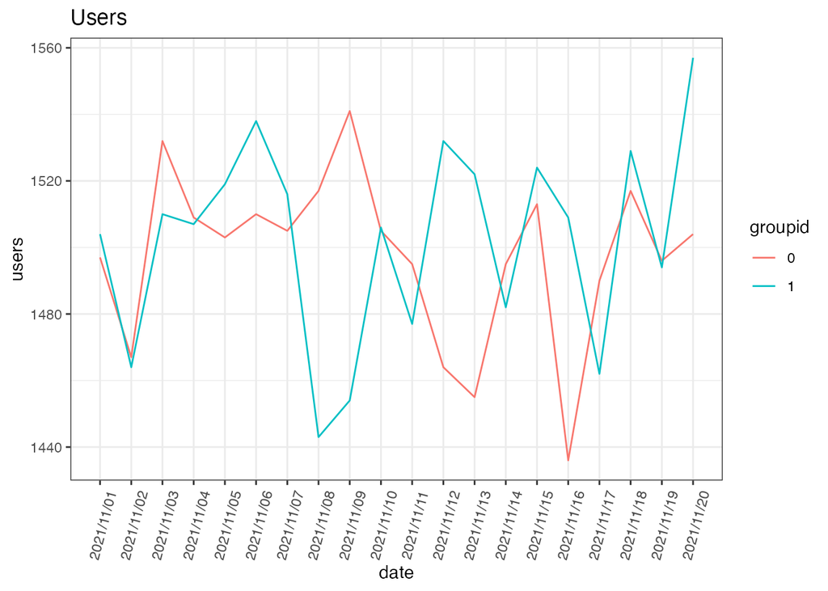

```r
assignments %>%
  group_by(groupid, dt) %>%
  count() %>%
  ggplot(., aes(dt, n, col = as.factor(groupid))) +
  geom_line() +
  scale_x_date(
    labels = date_format("%Y/%m/%d"),
    breaks = "1 day",
    minor_breaks = "1 day"
  )  + labs(
    title = "Users",
    x = "date",
    y = "users",
    col = "groupid"
    ) +
  theme_bw() +
  theme(axis.text.x = element_text(
    angle = 75,
    vjust = 0.2,
    hjust = 0.2
  ))
```

次に、事前テストメトリクスを調べてみましょう。ユーザーアクティビティのファイルがあり、それを読み込んで調べる。各ユーザーについて、各日におけるグループIDとアクティビティレベルが記録されている。

```r
activity_all <- read_csv("~/Desktop/activity_all.csv")
head(activity_all)
```

```
## # A tibble: 6 × 4
##   userid                               dt         groupid activity_level
##   <chr>                                <date>       <dbl>          <dbl>
## 1 a5b70ae7-f07c-4773-9df4-ce112bc9dc48 2021-10-01       0              0
## 2 d2646662-269f-49de-aab1-8776afced9a3 2021-10-01       0              0
## 3 c4d1cfa8-283d-49ad-a894-90aedc39c798 2021-10-01       1              0
## 4 6889f87f-5356-4904-a35a-6ea5020011db 2021-10-01       0              0
## 5 dbee604c-474a-4c9d-b013-508e5a0e3059 2021-10-01       1              0
## 6 9b2f41cf-350d-4073-b9d4-3848d0c0b1b5 2021-10-01       1              0
```

```r
activity_all %>%
  group_by(groupid, dt) %>%
    summarise(
    count = n(),
    mean = mean(activity_level),
    std = sd(activity_level),
    min = min(activity_level),
    `q25%` = quantile(activity_level, 0.25),
    `q50%` = quantile(activity_level, 0.50),
    `q75%` = quantile(activity_level, 0.75),
    max = max(activity_level)
  )
```

```
## # A tibble: 122 × 10
## # Groups:   groupid [2]
##    groupid dt         count  mean   std   min `q25%` `q50%` `q75%`   max
##      <dbl> <date>     <int> <dbl> <dbl> <dbl>  <dbl>  <dbl>  <dbl> <dbl>
##  1       0 2021-10-01 29951  5.24  6.52     0      0      1     10    20
##  2       0 2021-10-02 29951  5.26  6.51     0      0      1     10    20
##  3       0 2021-10-03 29951  5.27  6.51     0      0      1     10    20
##  4       0 2021-10-04 29951  5.21  6.51     0      0      1     10    20
##  5       0 2021-10-05 29951  5.18  6.51     0      0      1     10    20
##  6       0 2021-10-06 29951  5.22  6.50     0      0      1     10    20
##  7       0 2021-10-07 29951  5.26  6.52     0      0      1     10    20
##  8       0 2021-10-08 29951  5.29  6.55     0      0      1     11    20
##  9       0 2021-10-09 29951  5.22  6.49     0      0      1     10    20
## 10       0 2021-10-10 29951  5.24  6.53     0      0      1     11    20
## # ℹ 112 more rows
```

次に、ユーザーアクティビティを異なる視点から見る。ユーザーが1日に何回アクティブであるかではなく、その日に少なくとも1回アプリケーションにアクセスしたユーザーの数を調べる。このために、その日に少なくとも1回アクティブだったユーザーの数を計算する。

```r
activity_all %>%
  filter(activity_level > 0) %>%
  group_by(dt, groupid) %>%
  summarise(
    users = n_distinct(userid)
  )
```

```
## # A tibble: 122 × 3
## # Groups:   dt [61]
##    dt         groupid users
##    <date>       <dbl> <int>
##  1 2021-10-01       0 15337
##  2 2021-10-01       1 15297
##  3 2021-10-02       0 15354
##  4 2021-10-02       1 15421
##  5 2021-10-03       0 15423
##  6 2021-10-03       1 15362
##  7 2021-10-04       0 15211
##  8 2021-10-04       1 15388
##  9 2021-10-05       0 15126
## 10 2021-10-05       1 15462
## # ℹ 112 more rows
```

この計算結果から、テスト開始から11月1日までの間で、テストグループの方がはるかにアクティブであることが分かります。テストグループでは、少なくとも1回はアクティブなユーザーが約29,000人で、一方、コントロールグループでは事前のレベルを保持していることが分かる。

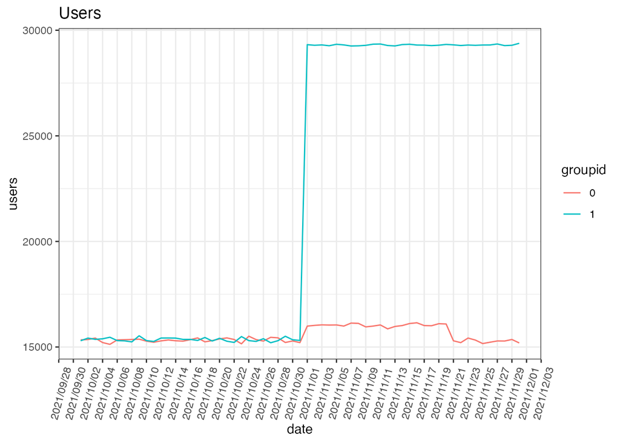

```r
activity_all %>%
  filter(activity_level > 0) %>%
  group_by(dt, groupid) %>%
  summarise(
    users = n_distinct(userid)
  ) %>%
  ggplot(., aes(dt, users, col = as.factor(groupid))) +
  geom_line() +
  scale_x_date(
    labels = date_format("%Y/%m/%d"),
    breaks = "2 day",
    minor_breaks = "2 day"
  )  + labs(
    title = "Users",
    x = "date",
    y = "users",
    col = "groupid"
    ) +
  theme_bw() +
  theme(axis.text.x = element_text(
    angle = 75,
    vjust = 0.2,
    hjust = 0.2
  ))
```

```r
activity_all %>%
  filter(activity_level > 0 & dt >= '2021-11-01') %>%
  group_by(groupid, dt) %>%
  summarise(users = n_distinct(userid))  %>%
  group_by(groupid) %>%
  summarise(
    count = n(),
    mean = mean(users),
    std = sd(users),
    min = min(users),
    `q25%` = quantile(users, 0.25),
    `q50%` = quantile(users, 0.50),
    `q75%` = quantile(users, 0.75),
    max = max(users)
  )
```

```
## # A tibble: 2 × 9
##   groupid count   mean   std   min `q25%` `q50%` `q75%`   max
##     <dbl> <int>  <dbl> <dbl> <int>  <dbl>  <dbl>  <dbl> <int>
## 1       0    30 15782  371.  15163  15335 15990.  16045 16147
## 2       1    30 29302.  30.4 29255  29280 29300   29321 29382
```

次に、ユーザーが平均で1日中にアクティブだった回数を調べる。平均して、テスト開始後、コントロールグループでは1日に平均して約5回アクティブであり

```r
activity_all %>%
  filter(dt < '2021-11-01') %>%
  group_by(groupid) %>%
  summarise(
    count = n(),
    mean = mean(activity_level),
    std = sd(activity_level),
    min = min(activity_level),
    `q25%` = quantile(activity_level, 0.25),
    `q50%` = quantile(activity_level, 0.50),
    `q75%` = quantile(activity_level, 0.75),
    max = max(activity_level)
  )
```

```
## # A tibble: 2 × 9
##   groupid  count  mean   std   min `q25%` `q50%` `q75%`   max
##     <dbl>  <int> <dbl> <dbl> <dbl>  <dbl>  <dbl>  <dbl> <dbl>
## 1       0 928481  5.25  6.52     0      0      1     10    20
## 2       1 931519  5.24  6.52     0      0      1     10    20
```

施策実施後のテストグループでは1日に平均して9回または10回アクティブであることが分かる。テスト開始前の時点では、テストグループとコントロールグループでこれらの数字は非常に類似している。したがって、事前テストバイアスはなく、グループは実際に比較可能であることが分かる。違いは実際にABテストから生じている。

```r
activity_all %>%
  filter(dt >= '2021-11-01') %>%
  group_by(groupid) %>%
  summarise(
    count = n(),
    mean = mean(activity_level),
    std = sd(activity_level),
    min = min(activity_level),
    `q25%` = quantile(activity_level, 0.25),
    `q50%` = quantile(activity_level, 0.50),
    `q75%` = quantile(activity_level, 0.75),
    max = max(activity_level)
  )
```

```
## # A tibble: 2 × 9
##   groupid  count  mean   std   min `q25%` `q50%` `q75%`   max
##     <dbl>  <int> <dbl> <dbl> <dbl>  <dbl>  <dbl>  <dbl> <dbl>
## 1       0 898530  5.40  6.56     0      0      1     11    20
## 2       1 901470 10.0   5.79     0      5     10     15    20
```

施策期間前のグループ間のアクティビティを比較し、統計的有意性とp値を計算するためにt検定を使用する。

```r
before <- activity_all %>% filter(dt <  '2021-11-01')
after  <- activity_all %>% filter(dt >= '2021-11-01')

before %>%
  group_by(groupid) %>%
  summarise(mean_activity_level = mean(activity_level))
```

```
## # A tibble: 2 × 2
##   groupid mean_activity_level
##     <dbl>               <dbl>
## 1       0                5.25
## 2       1                5.24
```

t検定の結果は下記の通り。

```r
data_group0 <- before %>% filter(groupid == 0) %>% pull(activity_level)
data_group1 <- before %>% filter(groupid == 1) %>% pull(activity_level)

result <- t.test(data_group0, data_group1)
print(result)
```

```
##
##  Welch Two Sample t-test
##
## data:  data_group0 and data_group1
## t = 0.4897, df = 1859977, p-value = 0.6243
## alternative hypothesis: true difference in means is not equal to 0
## 95 percent confidence interval:
##  -0.01405996  0.02342582
## sample estimates:
## mean of x mean of y
##  5.245635  5.240952
```

施策期間中のt検定の結果は下記の通りで、`activity_level`が平均して4回ほど多い。

```r
data_group0 <- after %>% filter(groupid == 0) %>% pull(activity_level)
data_group1 <- after %>% filter(groupid == 1) %>% pull(activity_level)

result <- t.test(data_group0, data_group1)
print(result)
```

```
##
##  Welch Two Sample t-test
##
## data:  data_group0 and data_group1
## t = -498.3, df = 1771420, p-value < 2.2e-16
## alternative hypothesis: true difference in means is not equal to 0
## 95 percent confidence interval:
##  -4.612162 -4.576022
## sample estimates:
## mean of x mean of y
##  5.402211  9.996304
```

クリックスルー率の結果も確認する。

```r
data_ctr <- read_csv("~/Desktop/ctr_all.csv")
data_ctr
```

```
## # A tibble: 2,303,408 × 4
##    userid                               dt         groupid   ctr
##    <chr>                                <date>       <dbl> <dbl>
##  1 60389fa7-2d71-4cdf-831c-c2bb277ffa1e 2021-11-13       0  31.8
##  2 b59cb225-d160-4851-92d2-7cc8120a2f63 2021-11-13       0  30.5
##  3 aa336050-934e-453f-a5b0-dd881fcd114e 2021-11-13       0  34.2
##  4 8df767f4-a10f-4322-a722-676b7e02b372 2021-11-13       0  34.9
##  5 a74762ed-4da0-42ab-91d2-40d7e808dfe9 2021-11-13       0  35.0
##  6 f29006ed-15ec-41d5-872e-885f9e75c558 2021-11-13       0  35.1
##  7 27cfe22e-f4b5-4c2e-9dd5-5b96eb062ca8 2021-11-13       0  31.5
##  8 0e8182a7-48d4-45af-a3b6-8caa8aa6eb5b 2021-11-13       0  34.3
##  9 c79f4b4c-2141-4c27-8934-7cc1ab411d49 2021-11-13       0  34.8
## 10 604a5580-8271-47e8-89dc-fa4b5fdf0c52 2021-11-13       0  30.7
## # ℹ 2,303,398 more rows
```

可視化すると、明らかに施策の効果が見て取れる。

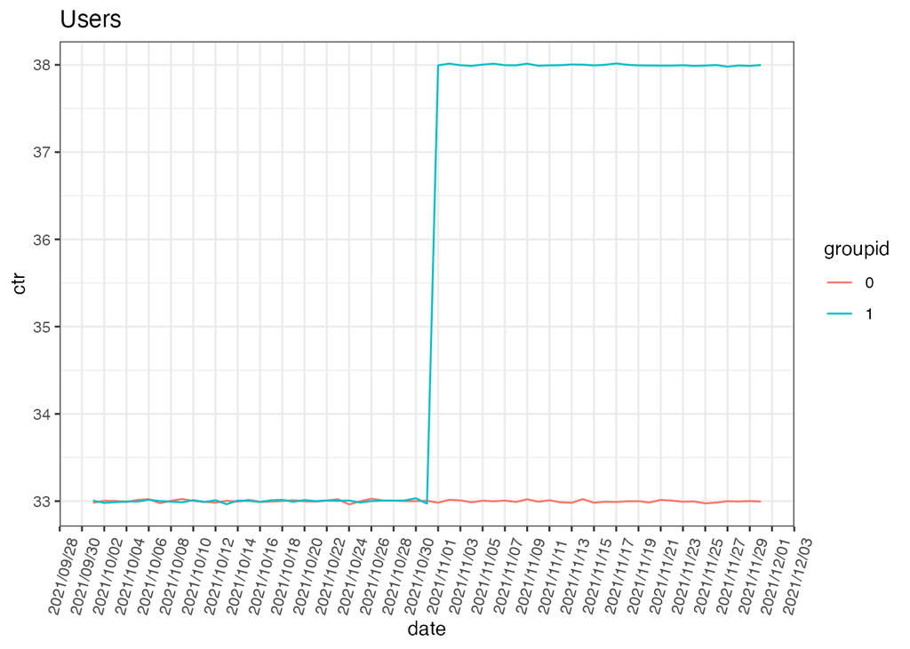

```r
data_ctr %>%
  group_by(dt, groupid) %>%
  summarise(
    mean_ctr = mean(ctr)
  ) %>%
  ggplot(., aes(dt, mean_ctr, col = as.factor(groupid))) +
  geom_line() +
  scale_x_date(
    labels = date_format("%Y/%m/%d"),
    breaks = "2 day",
    minor_breaks = "2 day"
  )  + labs(
    title = "Users",
    x = "date",
    y = "ctr",
    col = "groupid"
    ) +
  theme_bw() +
  theme(axis.text.x = element_text(
    angle = 75,
    vjust = 0.2,
    hjust = 0.2
  ))
```

アクティビティデータと同様に、テスト開始前とテスト後のクリックスルー率を調査する。テスト開始前のデータはクリックスルー率がほぼ同じであることを示しています。テスト開始後、クリックスルー率におおよそ 5%の違いがあることが分かる。標準偏差にはともに1.7%。検定するまでもなく、クリックスルー率は5%の増加を示しており、テストは成功したといえる。

```r
pre <- data_ctr %>%
  filter(dt < '2021-11-01') %>%
  group_by(groupid) %>%
  summarise(
    mean = mean(ctr),
    std = sd(ctr)
  ) %>%
  mutate(term = 'pre')

post <- data_ctr %>%
  filter(dt >= '2021-11-01') %>%
  group_by(groupid) %>%
  summarise(
    mean = mean(ctr),
    std = sd(ctr)
  ) %>%
  mutate(term = 'post')

pre %>%
  bind_rows(post)
```

```
## # A tibble: 4 × 4
##   groupid  mean   std term
##     <dbl> <dbl> <dbl> <chr>
## 1       0  33.0  1.73 pre
## 2       1  33.0  1.73 pre
## 3       0  33.0  1.73 post
## 4       1  38.0  1.73 post
```

## 参考文献

- [A/B Testing in Python](https://www.udemy.com/course/ab-testing-in-python/)